# TBI dynamic FC

Ben Cowley

17 March 2019

# PARAMETERS

```
## [1] "ROI 1s are:  roi1_rifg  &  roi1_racc"
```

# DATA WRANGLING

After exporting subject-wise ROIs from Matlab data to csv files, we read all data into a single long-format data structure. We label this data with the condition, 1 = pre, 2 = post

# SYNCHRONY COMBINATIONS

Firstly, we work within each ROI combination indicated:

- roi 1 R IFG v roi 2 L HPC x cond 1
- roi 1 R IFG v roi 2 R NAC x cond 1
- roi 1 R ACC v roi 2 L STG x cond 1
- roi 1 R ACC v roi 2 R TPO x cond 1
- roi 1 R IFG v roi 2 L HPC x cond 2
- roi 1 R IFG v roi 2 R NAC x cond 2
- roi 1 R ACC v roi 2 L STG x cond 2
- roi 1 R ACC v roi 2 R TPO x cond 2

We calculate a sliding window median smoothing of the rsfMRI data, using window size = 10 and 50% overlap. Then comes the correlation matrix for each condition, with the intra-subject correlations on the diagonal, and inter-subject correlations off-diagonal. Diagonals (n-element vector, n = sample size) and their aggregate (scalar) are obtained for each condition (can be used for, e.g. within-subjects analysis of prognostics?)

To aggregate correlations, we take the mean (note that correlations can only be aggregated this way for constant N; to see why, note that Hunter-Schmidt correlation aggregate is equivalent to average for constant N). We also take the mean of absolute correlations, to estimate the unsigned magnitude of connectivity (but this is not used yet).

We finally plot the correlation matrix for each combination.

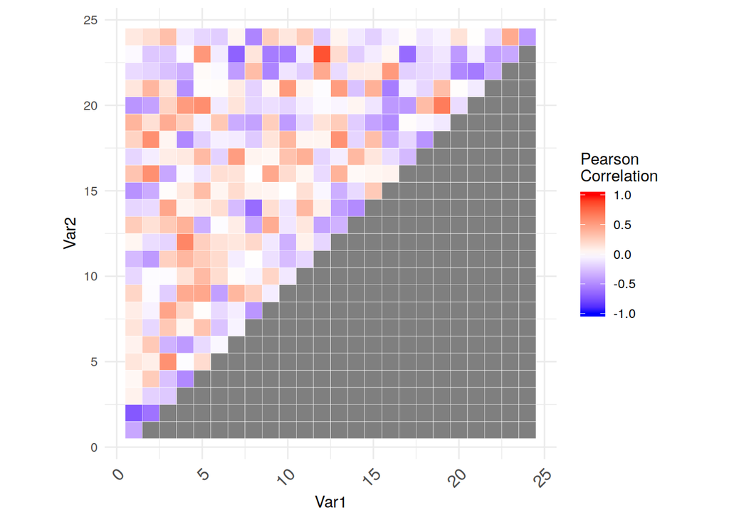

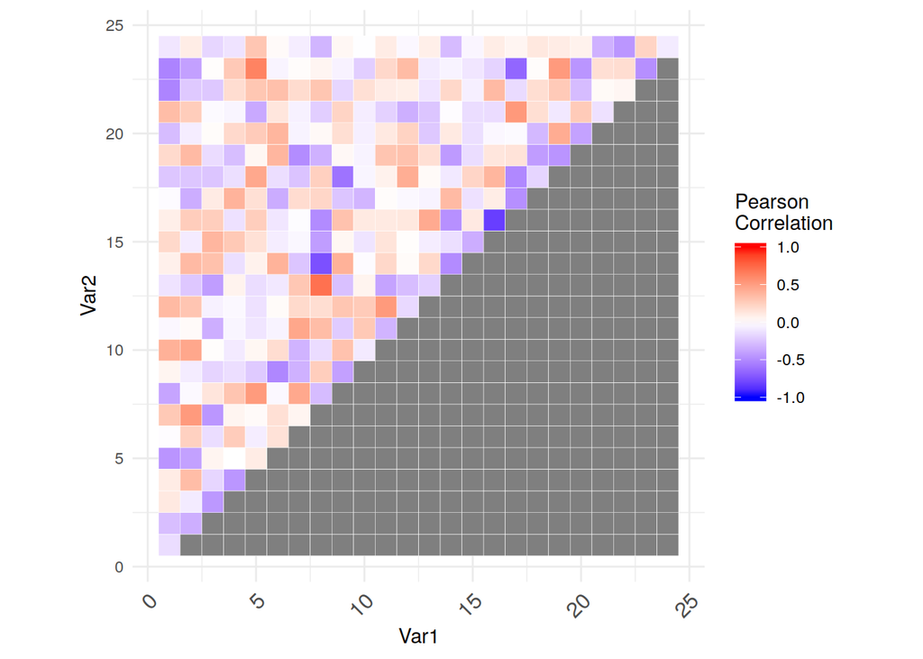

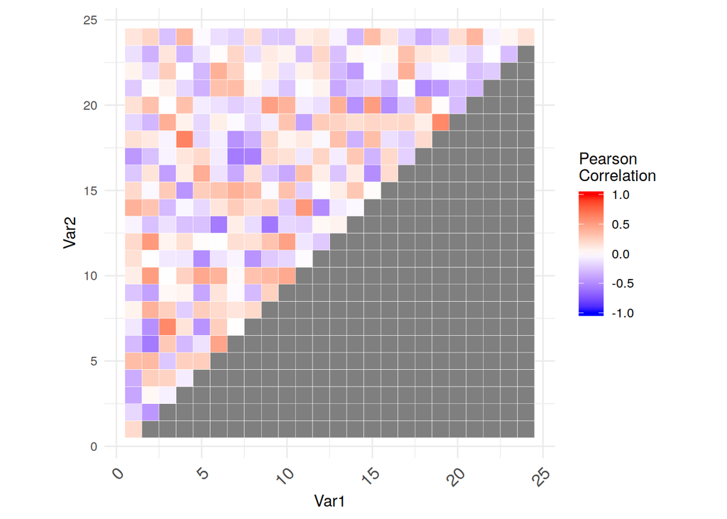

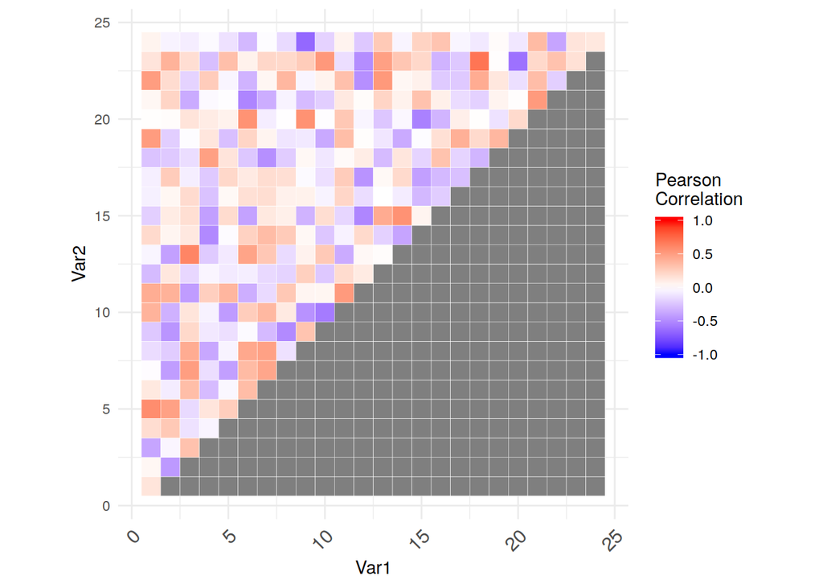

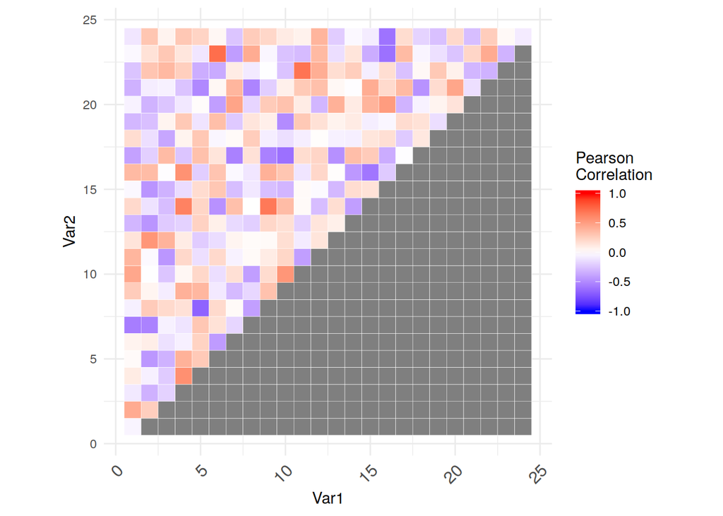

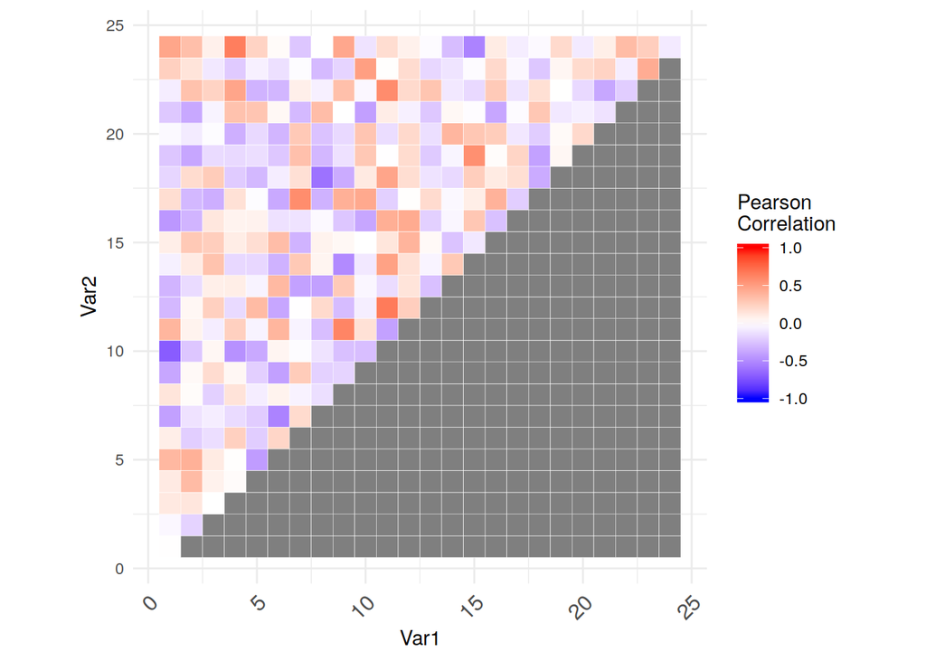

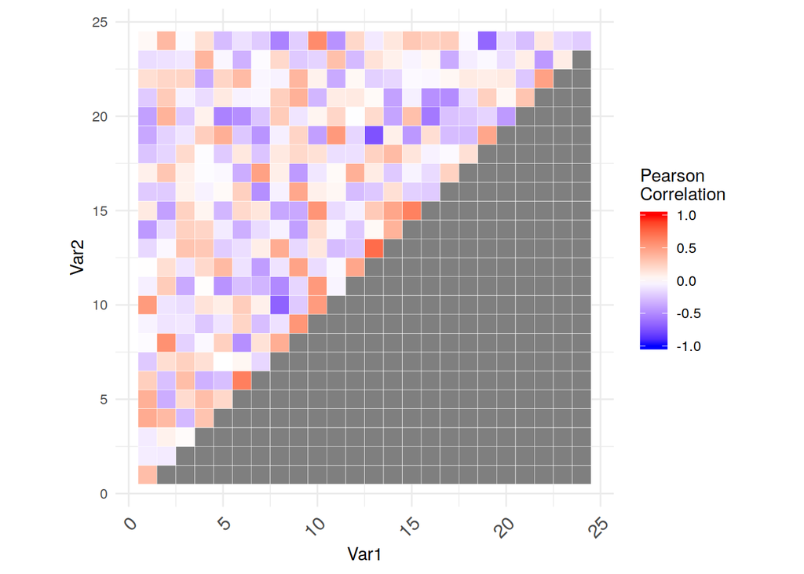

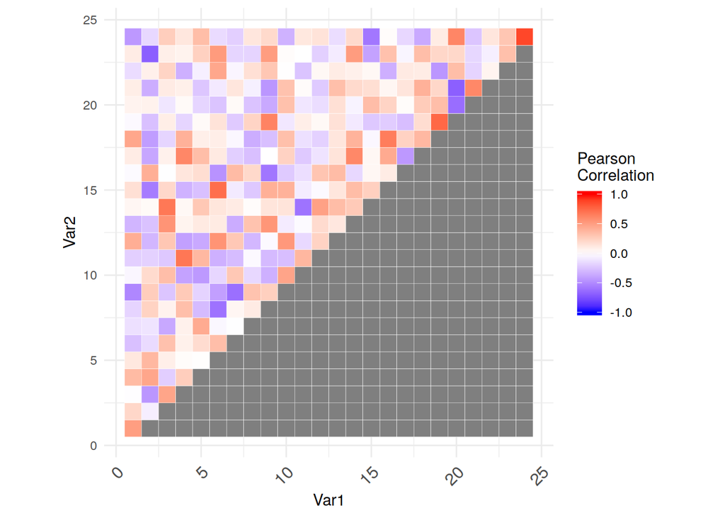

# MATRIX SAMPLING

To obtain a random sample (without replacement) of the pair-wise correlations, we simply shuffle the columns of each correlation matrix, which means we destroy matrix symmetry. An example is calculated and displayed below.

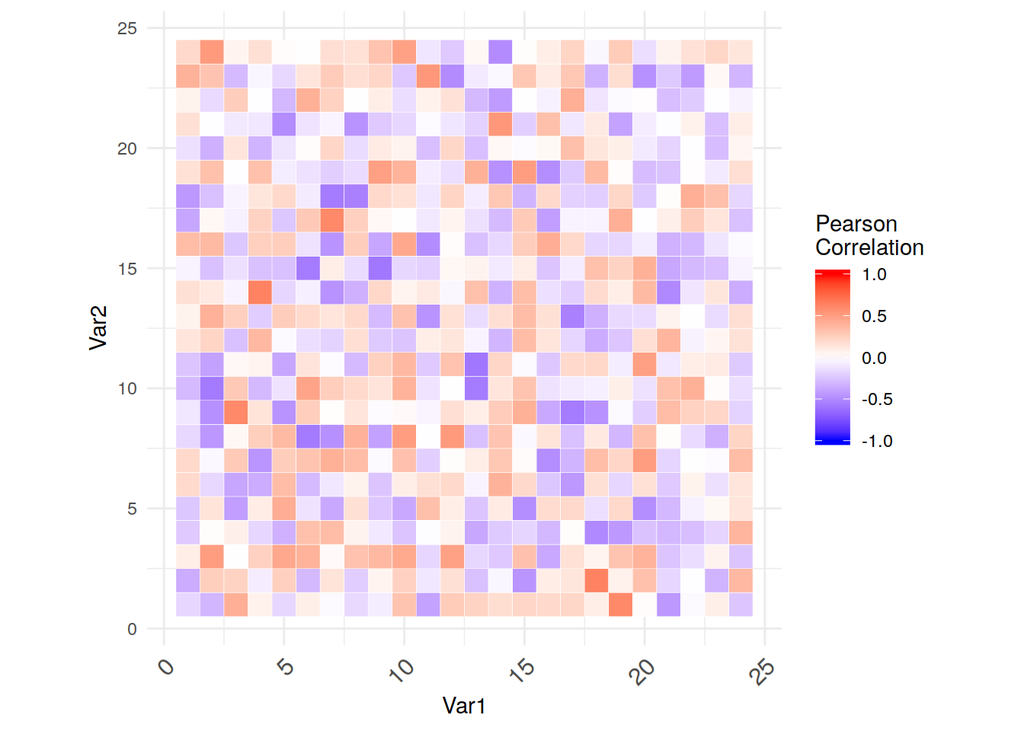

# PERMUTATION TESTING

To obtain a permutation test statistic, we repeat the random sampling 10000 times, generating a distribution of correlations. We plot the observed real correlation against the distribution to see the statistical difference of the obervation from a random distribution; actual *p*-value is computed by counting the proportion of random samples which lie *beyond* the observation, i.e. are absolutely greater. It is significantly different in 4 of 8 cases here: the underlying pattern seems to be that correlations increase during the intervention, comparing pre-test to post-test.

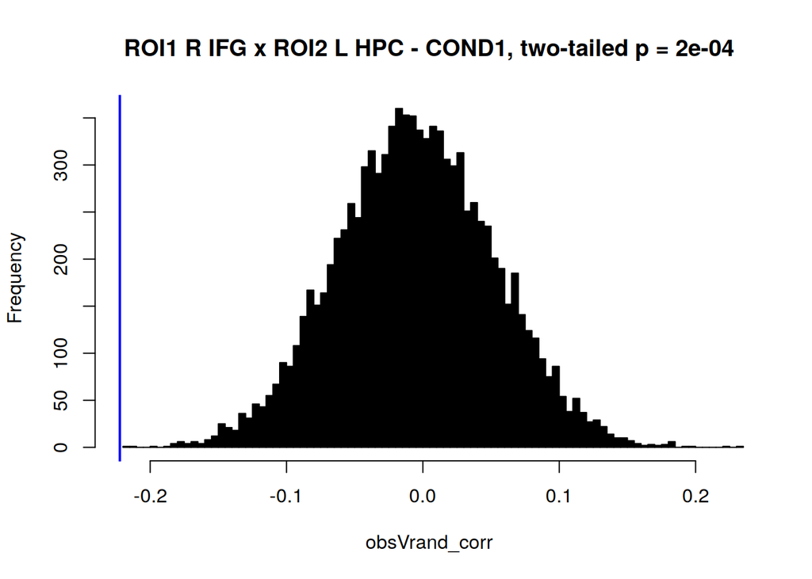

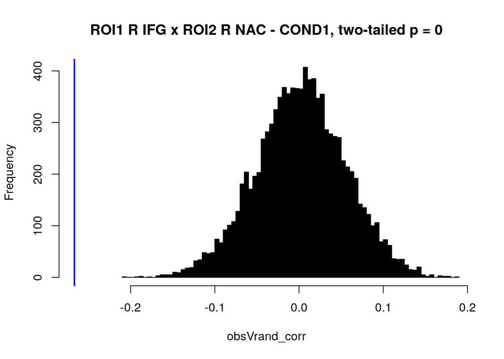

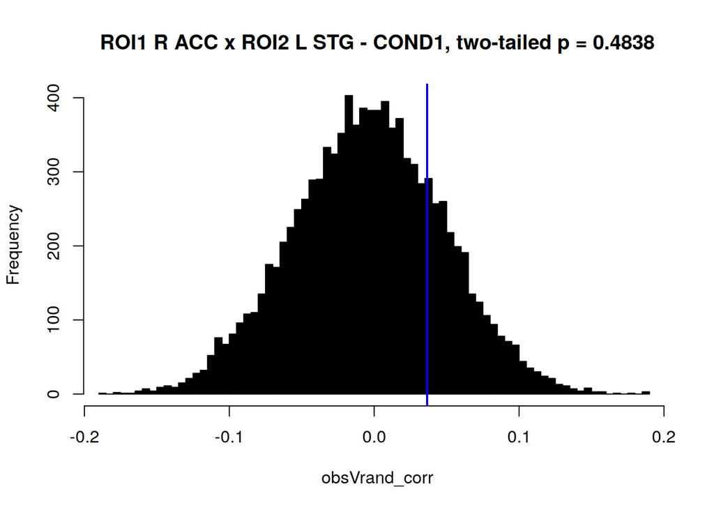

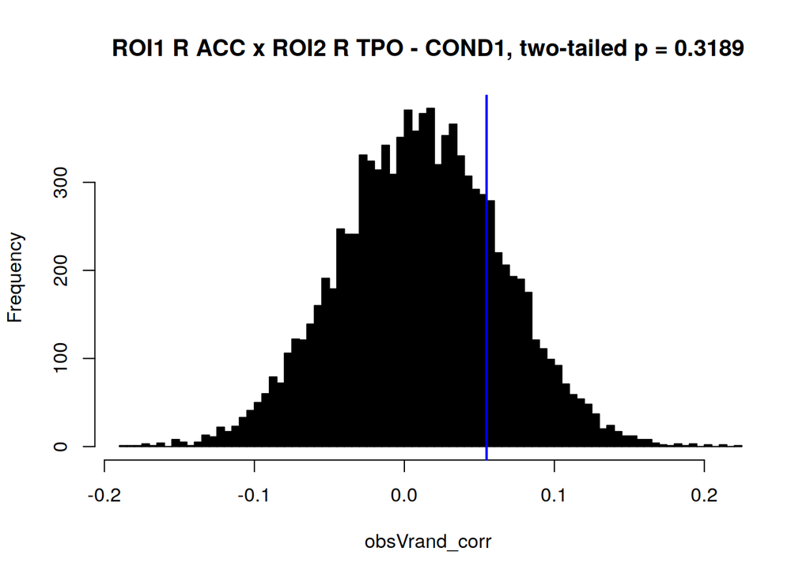

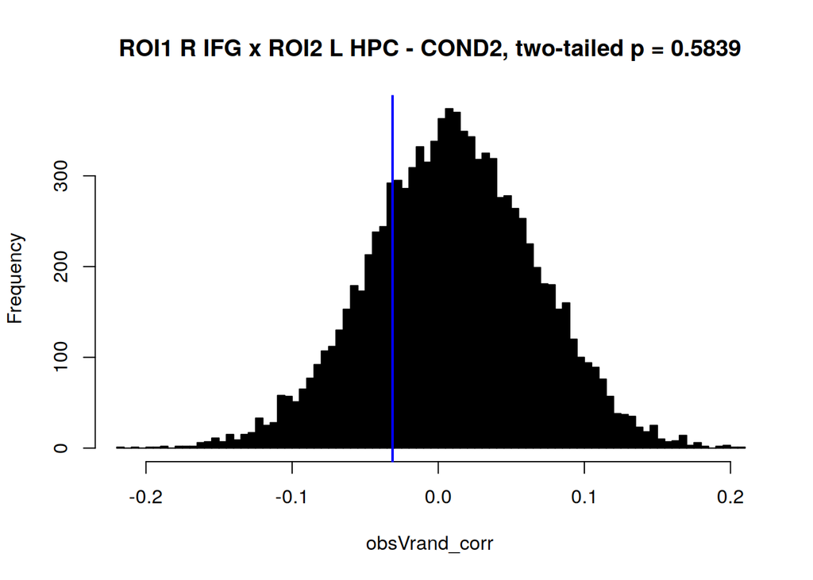

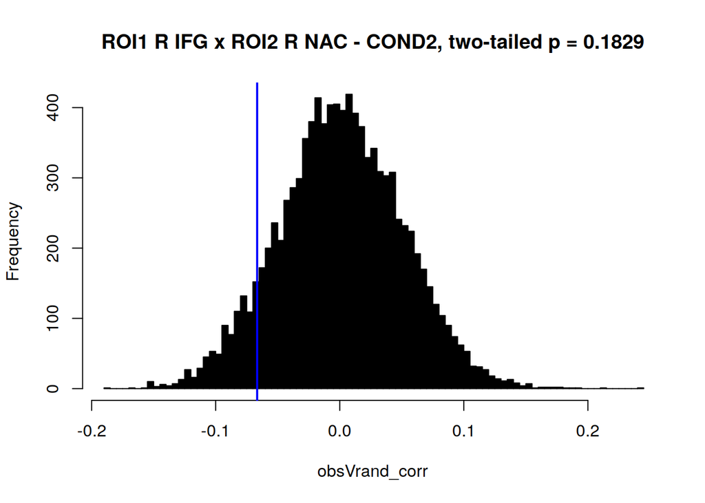

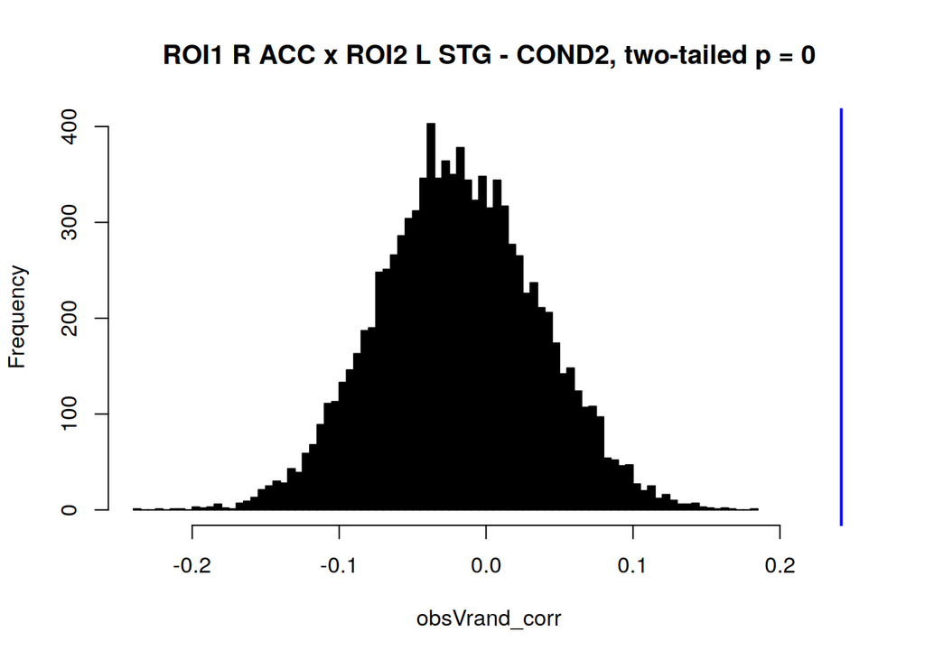

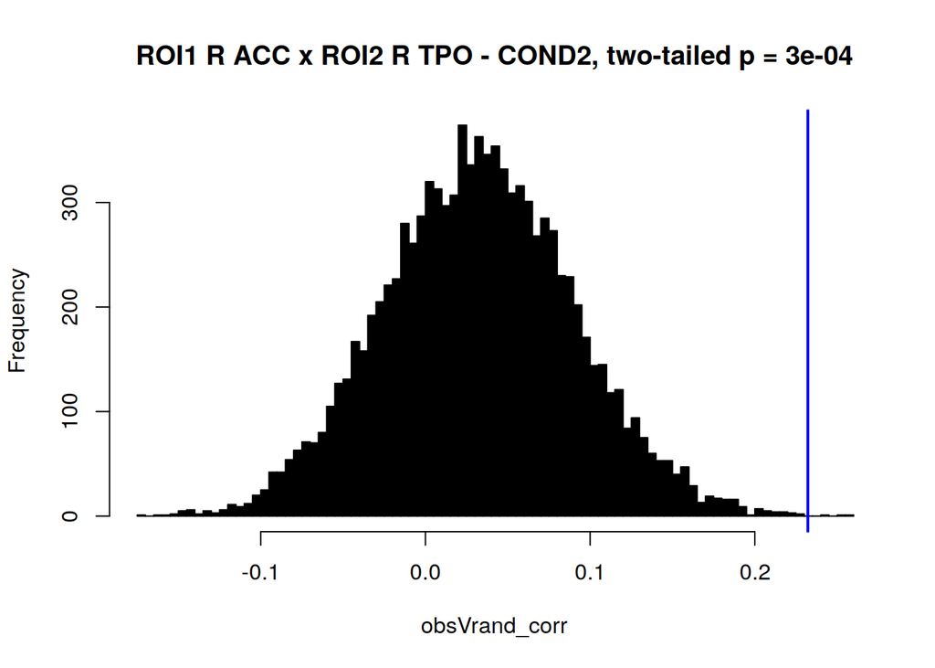

# TESTING PRE-POST

```
##
##  Welch Two Sample t-test
##
## data:  allc1.racc.lstg and allc2.racc.lstg
## t = -2.4346, df = 44.83, p-value = 0.01895
## alternative hypothesis: true difference in means is not equal to 0
## 95 percent confidence interval:
##  -0.37500020 -0.03542565
## sample estimates:
##  mean of x  mean of y
## 0.03654423 0.24175715
```

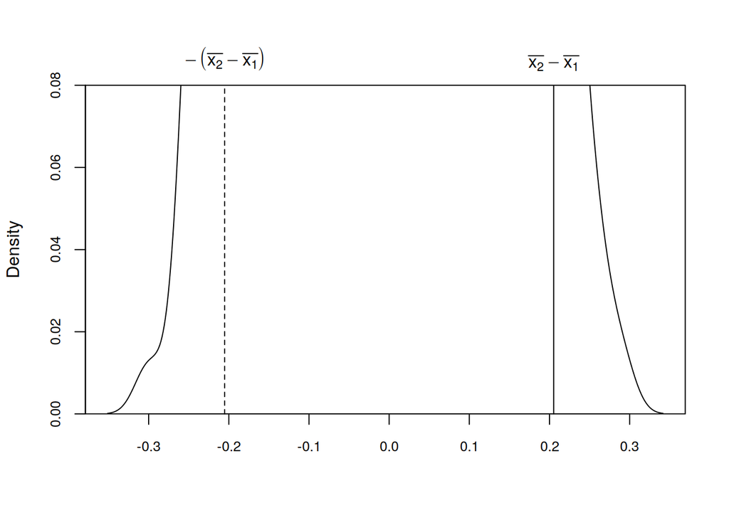

```
## p-value:
##    0.019
```

```
##
##  Two-sample Kolmogorov-Smirnov test
##
## data:  s1 and s2
## D = 0.41667, p-value = 0.02991
## alternative hypothesis: two-sided
```

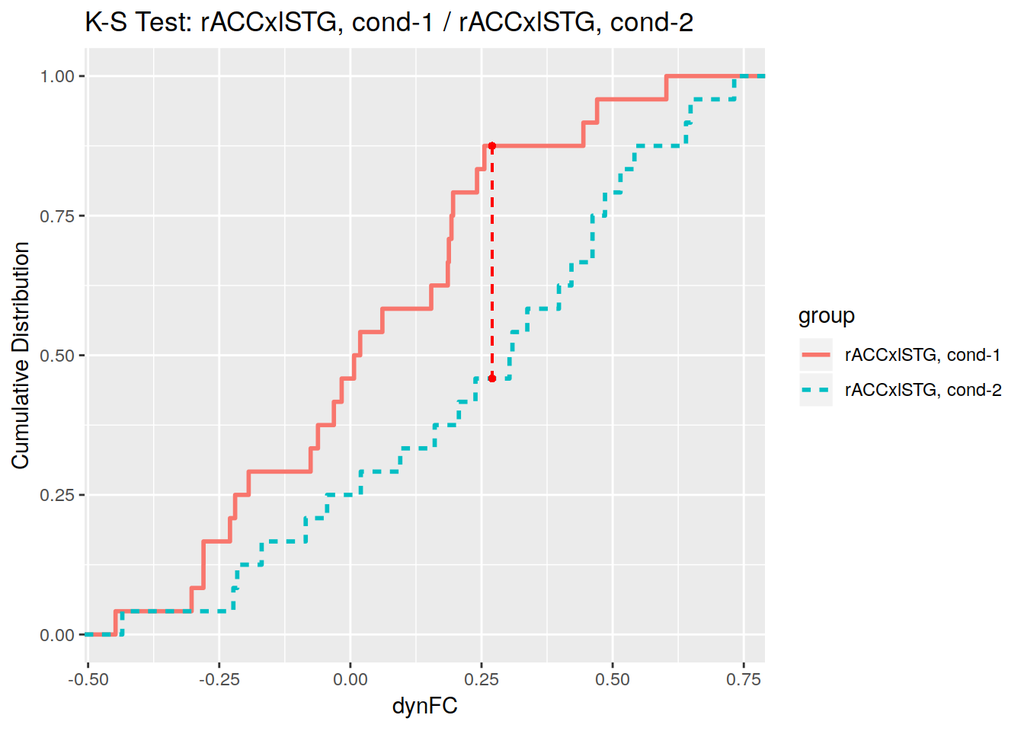

```
##
##  Welch Two Sample t-test
##
## data:  allc1.racc.rtpo and allc2.racc.rtpo
## t = -1.9031, df = 45.849, p-value = 0.06332
## alternative hypothesis: true difference in means is not equal to 0
## 95 percent confidence interval:
##  -0.36503017  0.01025493
## sample estimates:
##  mean of x  mean of y
## 0.05482181 0.23220944
```

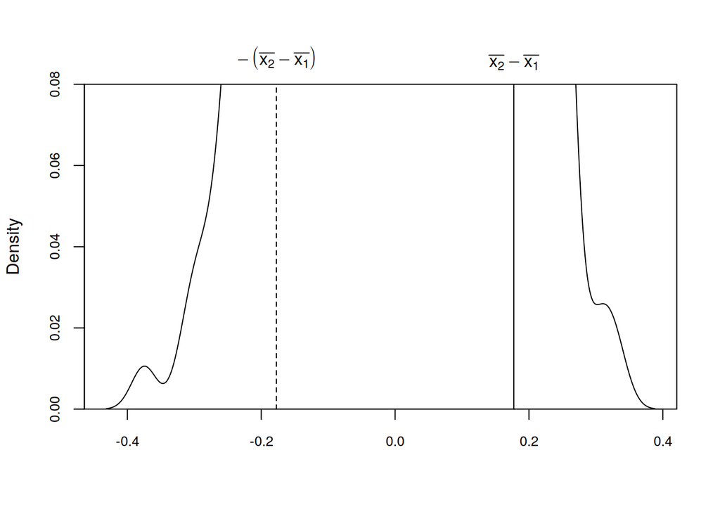

```
## p-value:
##   0.0625
```

```
##
##  Two-sample Kolmogorov-Smirnov test
##
## data:  s1 and s2
## D = 0.29167, p-value = 0.2628
## alternative hypothesis: two-sided
```

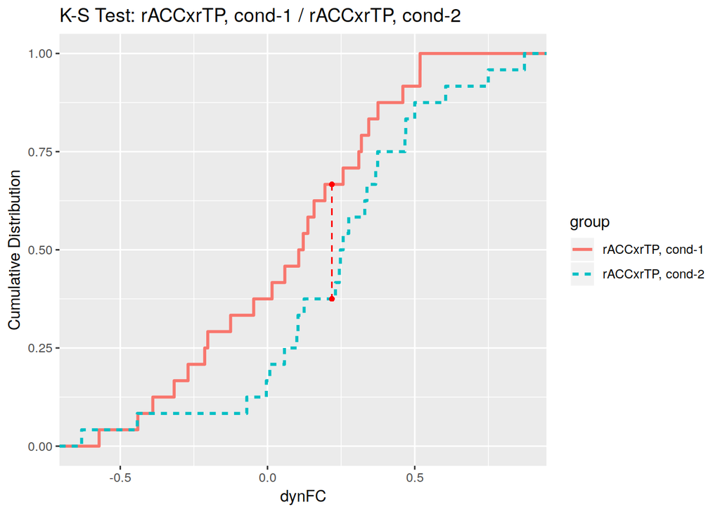

```
##
##  Welch Two Sample t-test
##
## data:  allc1.rifg.lhpc and allc2.rifg.lhpc
## t = -2.5116, df = 43.142, p-value = 0.01584
## alternative hypothesis: true difference in means is not equal to 0
## 95 percent confidence interval:
##  -0.34425833 -0.03764396
## sample estimates:
##   mean of x   mean of y
## -0.22223004 -0.03127889
```

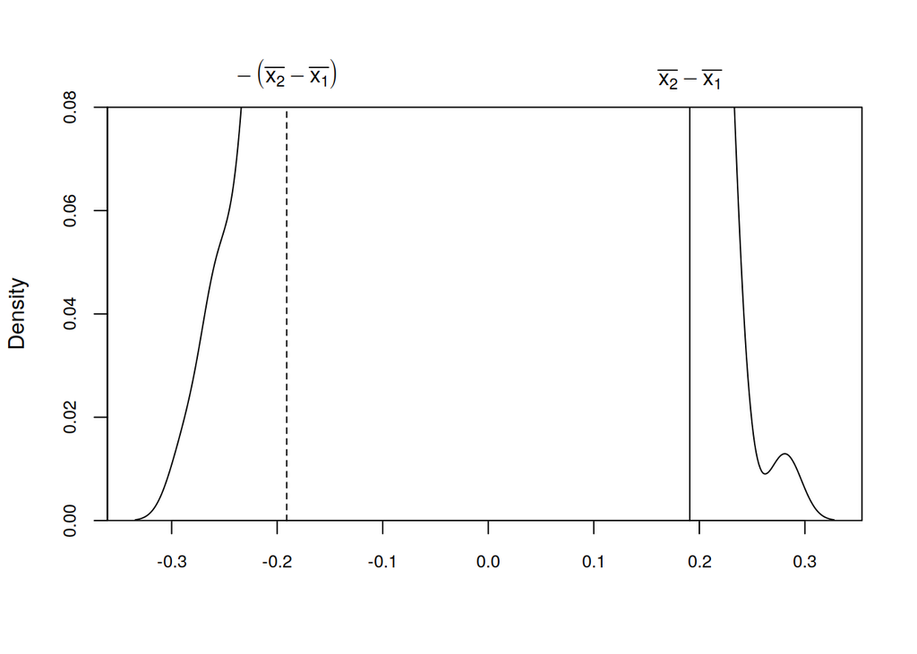

```
## p-value:
##    0.018
```

```
##
##  Two-sample Kolmogorov-Smirnov test
##
## data:  s1 and s2
## D = 0.33333, p-value = 0.1398
## alternative hypothesis: two-sided
```

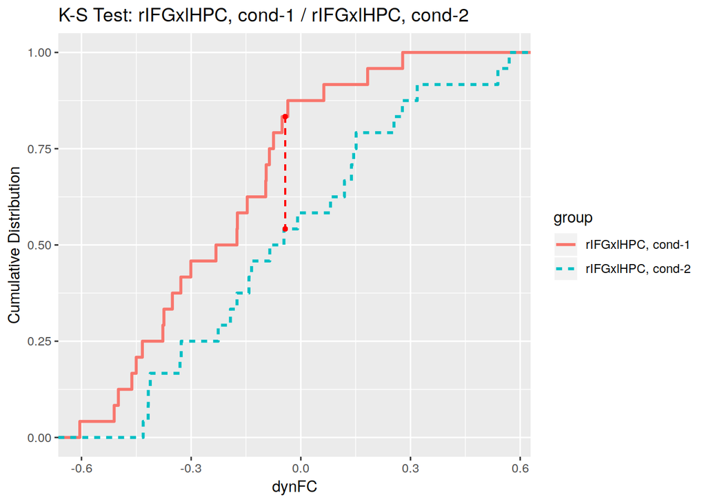

```
##
##  Welch Two Sample t-test
##
## data:  allc1.rifg.rnac and allc2.rifg.rnac
## t = -2.972, df = 46, p-value = 0.004695
## alternative hypothesis: true difference in means is not equal to 0
## 95 percent confidence interval:
##  -0.33572999 -0.06459309
## sample estimates:
##   mean of x   mean of y
## -0.26674122 -0.06657968
```

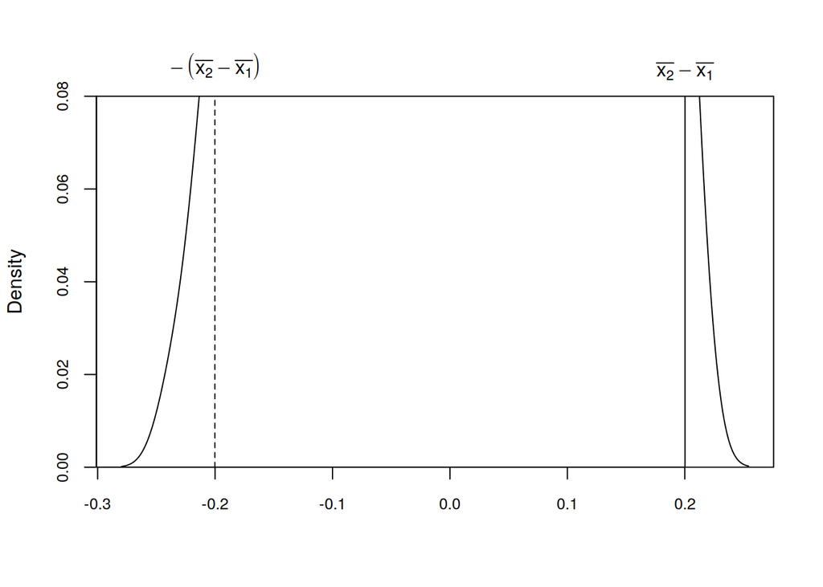

```
## p-value:
##    0.004
```

```
##
##  Two-sample Kolmogorov-Smirnov test
##
## data:  s1 and s2
## D = 0.41667, p-value = 0.02991
## alternative hypothesis: two-sided
```

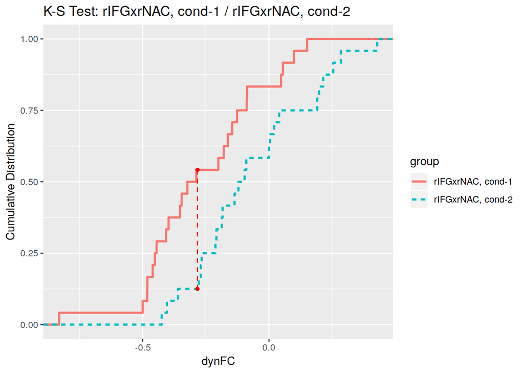